# Introduction to regression

Math 430, Winter 2017

## What is a statistical model?

- A model is a representation for a particular purpose (Daniel Kaplan)
- A simplification of reality (Cannon et al., 2010)
- A statistical model embodies a set of assumptions concerning the generation of the observed data, and similar data from a larger population (Wikipedia)
- Remember that all models are wrong; the practical question is how wrong do they have to be to not be useful (George Box)

## What is a statistical model?

### Notation

- \(Y_i\): **response variable** measured on the \(i^{\text{th}}\) *observational unit*, \(i=1,\ldots,n\)
- \(x_{i1}, x_{i2}, \ldots, x_{ik}\): **predictor/explanatory/covariate variables** measured on the \(i^{\text{th}}\) *observational unit*

### Statistical model

\[Y_i = f(x_{i1}, x_{i2}, \ldots, x_{ik}) + \varepsilon\]

where

- \(f(\cdot)\): a mathematical function
- \(\varepsilon\): a random error term

## Why do we model?

1. Prediction
2. Understanding relationships
3. Assessing differences

## Challenges we will face

### Data collection and variable selection

- What data do we need to achieve our goals?
- Can we use data to actually answer our questions?
- What types of variables do we have?
- What variables are actually important?

## Challenges we will face

### Model specification

- What is the "right" model to use?
- Does this choice help us achieve our goals?
- What assumptions are embedded in our choice?
- Are these assumptions valid?

## Challenges we will face

### Model specification

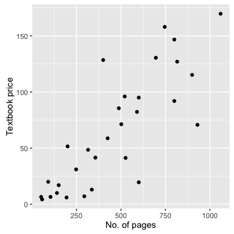

Need to choose \(f(x)\)

## Challenges we will face

### Model specification

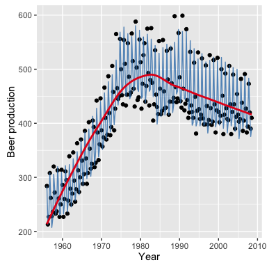

Need to choose \(f(x)\)

## Challenges we will face

### Model fitting

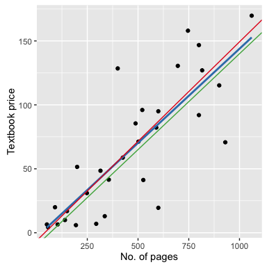

How can we estimate the unknown parameters in our model?

\[f(x) = \beta_0 + \beta_1x\]

What should \(\beta_0\) and \(\beta_1\) be?

## Challenges we will face

### Dealing with randomness

If our model is

\[Y_i = f(X_{i1}, X_{i2}, \ldots, X_{ik}) + \varepsilon\]

what distribution should \(\varepsilon\) follow?

## What are we going to do in Math 430?

### Model

- Learn the statistical modeling thought process
  1. Stating the problem in non-statistical terms
  2. Assessment of data quality
  3. Choose (specify) the model
  4. Fit the model
  5. Assess (validate) the model
  6. Use the model to answer the question(s)
- We will focus on regression models

## Logistics

### Textbook

- *A Modern Approach to Regression with R* by Simon J. Sheather, Springer, 2009
- One copy on 2-hour reserve at the Mudd

### Class sessions

- 2 days per week will focus on learning new methods
- Real examples emphasized

### Lab sessions

- 1 day each week will focus on making sure that you are comfortable with using R for statistical modeling

## Grading

### Homework (50%)

- Approximately weekly assignments
- Typically due Wednesdays by 4:30
- No late work

### Midterm (20%)

- To ensure that everyone is keeping up with the material

### Final project (30%)

- Carryout an entire analysis of data set you choose
- More information later

## Overview

### Topic

1. Simple linear regression
2. Multiple linear regression
3. Logistic regression

### Chapters

- 2–4
- 5–7
- 8

## A famous motivating example

### (Perhaps surprisingly, this example is still relevant)

http://www.nature.com/ejhg/journal/v17/n8/full/ejhg20095a.html

[Predicting height: the Victorian approach beats modern genomics](http://www.wired.com/wiredscience/2009/03/predicting-height-the-victorian-approach-beats-modern-genomics/)

## Galton's Data

- Let's look at the data first, used by Francis Galton in 1885.
- Galton was a statistician who invented the term and concepts of regression and correlation, founded the journal Biometrika, and was the cousin of Charles Darwin.
- You may need to run `install.packages("UsingR")` if the `UsingR` library is not installed.
- Let's look at the marginal (parents disregarding children and children disregarding parents) distributions first.
- Parent distribution is all heterosexual couples.
- Correction for gender via multiplying female heights by 1.08.
- Overplotting is an issue from discretization.

## Finding the middle via least squares

- Consider only the children's heights.
- How could one describe the "middle"?
- One definition, let \(Y_i\) be the height of child \(i\) for \(i = 1, \ldots, n = 928\), then define the middle as the value of \(\mu\) that minimizes \[\sum_{i=1}^n (Y_i - \mu)^2\]
- This is physical center of mass of the histrogram.
- You might have guessed that the answer \(\mu = \bar X\).

## The least squares estimate is the empirical mean

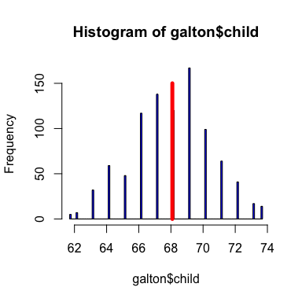

## Comparing childrens' heights and their parents' heights

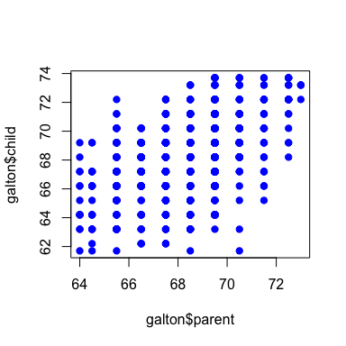

## Regression through the origin

- Suppose that \(X_i\) are the parents' heights.
- Consider picking the slope \(\beta\) that minimizes \[\sum_{i=1}^n (Y_i - X_i \beta)^2\]
- This is exactly using the origin as a pivot point picking the line that minimizes the sum of the squared vertical distances of the points to the line
- Use R studio's manipulate function to experiment
- Subtract the means so that the origin is the mean of the parent and children's heights

## The solution

### In the next few lectures we'll talk about why this is the solution

```
##
## Call:
## lm(formula = I(child - mean(child)) ~ I(parent - mean(parent)) -
##     1, data = galton)
##
## Coefficients:
## I(parent - mean(parent))
##                   0.6463
```

## Visualizing the best fit line

### Size of points are frequencies at that X, Y combination

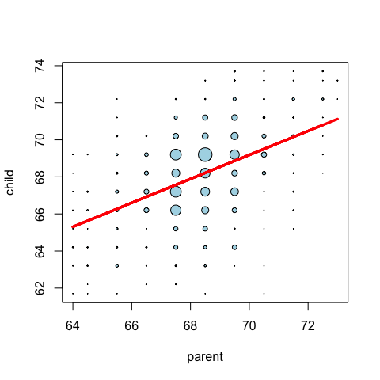